# HASYv2 dataset symbol recognition

In this project we will take a look at the fields of hand written symbol recognition. Handwriting recognition (HWR) belongs to the domain of image processing. Let's take a closer look to our dataset. We used the HASYv2 dataset to train Machine Learning algorithms to recognize 369 mathematical symbols.

In this jupyter notebook we will use the simple test- split model evaluation approach. We decided this regarding time- saving purposes.

To see the 10-fold validation & evaluation approach look at README.md.

# 1. Import & Pre- Processing

```python
import pandas as pd
data=pd.read_csv('hasy-data-labels.csv')
display(data.head())
```

|  | path | symbol_id | latex | user_id |
| --- | --- | --- | --- | --- |
| 0 | hasy-data/v2-00000.png | 31 | A | 50 |
| 1 | hasy-data/v2-00001.png | 31 | A | 10 |
| 2 | hasy-data/v2-00002.png | 31 | A | 43 |
| 3 | hasy-data/v2-00003.png | 31 | A | 43 |
| 4 | hasy-data/v2-00004.png | 31 | A | 4435 |

```python
data.groupby(['symbol_id'])['symbol_id'].count().plot('hist',bins=50).set_xlabel('symbol class size')
```

[output not shown]

```
Text(0.5,0,'symbol class size')
```

```python
print('The minimum number of symbols in a class is: '+ str(data.groupby(['symbol_id'])['symbol_id'].count().min()))
```

```
The minimum number of symbols in a class is: 51
```

Here we start to preprocess the picture data. The symbol labels and the path to the corresponding picture is saved in a hashtable: 'hasy-data-labels.csv'

```python
#Uncomment if you want to preprocess picture data & save it to np array, will take some time
'''
from keras.preprocessing import image
import numpy as np

#Here we devide (transform) the pictures by 255 and
def path_to_pic(path):
    img = image.load_img(path,target_size=(32, 32))
    x_data = image.img_to_array(img)[:,:,0]/255
    x_data= np.expand_dims(x_data, axis=0)
    return np.expand_dims(x_data, axis=3)

#column of paths
symbol_files = np.array(data['path'])
#column of labels
symbol_labels = np.array(data['symbol_id'])

#reshape in into a numpy array
Liste=list()
for path in symbol_files:
    Liste.append(path_to_pic(path))
data_picture=np.vstack(Liste)

#save reshaped dataset
np.save('outfiledata.npy', data_picture)

'''
```

[output not shown]

```python
#Here we import the preprocessed data
import numpy as np
import pandas as pd
data_picture=np.load('outfiledata.npy')
```

```python
from sklearn.model_selection import train_test_split
from sklearn import preprocessing

#Import of symbol labels
data=pd.read_csv('hasy-data-labels.csv')
data_label=data[['symbol_id']].astype('str')
data_label=np.array(pd.get_dummies(data_label))

#Here we split data, random state to guarantee reproducibility
X_train, X_test, y_train, y_test = train_test_split(data_picture, data_label, test_size=0.15, random_state=42)
X_train, X_validate, y_train, y_validate = train_test_split(X_train, y_train, test_size=0.15, random_state=42)
```

# 2. Training Neural Networks

Below we will consider some different Neural Network architectures:

## First CNN Model Architecture

We have pre-processed the dataset and split it up in training and test data. Lets start the action :

```python
#First try
from keras.layers import Conv2D, MaxPooling2D, GlobalAveragePooling2D
from keras.layers import Dropout, Flatten, Dense
from keras.models import Sequential
from keras.layers import Activation
from keras.callbacks import ModelCheckpoint

model_1 = Sequential()
model_1.add(Conv2D(16,input_shape=(32,32,1),kernel_size=3, padding='same',activation='relu'))
model_1.add(MaxPooling2D(2))
model_1.add(GlobalAveragePooling2D())
model_1.add(Dense(369,activation='softmax'))

#Generate summary
model_1.summary()
model_1.compile(optimizer='rmsprop',loss ='categorical_crossentropy', metrics=['accuracy'])
```

```
_________________________________________________________________
Layer (type)                 Output Shape              Param #
=================================================================
conv2d_1 (Conv2D)            (None, 32, 32, 16)        160
_________________________________________________________________
max_pooling2d_1 (MaxPooling2 (None, 16, 16, 16)        0
_________________________________________________________________
global_average_pooling2d_1 ( (None, 16)                0
_________________________________________________________________
dense_1 (Dense)              (None, 369)               6273
=================================================================
Total params: 6,433
Trainable params: 6,433
Non-trainable params: 0
_________________________________________________________________
```

# Training

```python
epochs = 5
checkpointer = ModelCheckpoint(filepath='HASYv2_FirstCNN.hdf5', verbose=1, save_best_only=True)
model_1.fit(X_train, y_train, epochs=epochs, batch_size=20,validation_data=(X_validate,y_validate),callbacks=[checkpointer] )
```

```
Train on 121548 samples, validate on 21450 samples

Epoch 00001: val_loss improved from inf to 5.27523, saving model to HASYv2_FirstCNN.hdf5

Epoch 00002: val_loss improved from 5.27523 to 5.08470, saving model to HASYv2_FirstCNN.hdf5

Epoch 00003: val_loss improved from 5.08470 to 4.85170, saving model to HASYv2_FirstCNN.hdf5

Epoch 00004: val_loss improved from 4.85170 to 4.65138, saving model to HASYv2_FirstCNN.hdf5

Epoch 00005: val_loss improved from 4.65138 to 4.49165, saving model to HASYv2_FirstCNN.hdf5
```

```
<keras.callbacks.History at 0x1154c3a90>
```

## Evaluate

```python
from keras.models import load_model
model_1.load_weights('HASYv2_FirstCNN.hdf5')
score=model_1.evaluate(X_test,y_test)
print('We receive an accuracy of: ' + str(score[1]) + ' on the test data.')
```

```
We receive an accuracy of: 0.16037249851426394 on the test data.
```

## First Fully Connected NN Model Architecture

```python
from keras.layers import Conv2D, MaxPooling2D, GlobalAveragePooling2D,Dropout, Flatten, Dense,Activation
from keras.models import Sequential

model_2 = Sequential()
model_2.add(Flatten(input_shape = X_train[1,:,:,].shape))
model_2.add(Dense(369,activation='softmax'))
model_2.add(Dense(1024,activation='softmax'))
model_2.add(Dense(369,activation='softmax'))
model_2.summary()

model_2.compile(optimizer='rmsprop',loss ='categorical_crossentropy', metrics=['accuracy'])
```

```
_________________________________________________________________
Layer (type)                 Output Shape              Param #
=================================================================
flatten_1 (Flatten)          (None, 1024)              0
_________________________________________________________________
dense_2 (Dense)              (None, 369)               378225
_________________________________________________________________
dense_3 (Dense)              (None, 1024)              378880
_________________________________________________________________
dense_4 (Dense)              (None, 369)               378225
=================================================================
Total params: 1,135,330
Trainable params: 1,135,330
Non-trainable params: 0
_________________________________________________________________
```

## Training

```python
epochs = 5
checkpointer = ModelCheckpoint(filepath='HASYv2_FCNN.hdf5', verbose=1, save_best_only=True)
model_2.fit(X_train, y_train,epochs=epochs, batch_size=20,validation_data=(X_validate,y_validate),callbacks=[checkpointer] )
```

```
Train on 121548 samples, validate on 21450 samples

Epoch 00001: val_loss improved from inf to 5.19947, saving model to HASYv2_FCNN.hdf5

Epoch 00002: val_loss improved from 5.19947 to 5.06124, saving model to HASYv2_FCNN.hdf5

Epoch 00003: val_loss improved from 5.06124 to 4.97134, saving model to HASYv2_FCNN.hdf5

Epoch 00004: val_loss improved from 4.97134 to 4.88183, saving model to HASYv2_FCNN.hdf5

Epoch 00005: val_loss improved from 4.88183 to 4.86980, saving model to HASYv2_FCNN.hdf5
```

```
<keras.callbacks.History at 0x1165fab00>
```

## Evaluate

```python
from keras.models import load_model
model_2.load_weights('HASYv2_FCNN.hdf5')
score=model_2.evaluate(X_test,y_test)
print('We received an accuracy of ' + str(round(score[1],2)) + ' on the test data.')
```

```
We received an accuracy of 0.06 on the test data.
```

## Final CNN Model Architecture

```python
#... Many trys later:
from keras.layers import Conv2D, MaxPooling2D, GlobalAveragePooling2D,Dropout, Flatten, Dense,Activation
from keras.models import Sequential

model_3 = Sequential()
model_3.add(Conv2D(32,input_shape=(32,32,1),kernel_size=2, padding='same',activation='relu'))
model_3.add(MaxPooling2D(2))
model_3.add(Conv2D(32,kernel_size=2,activation='relu'))
model_3.add(MaxPooling2D(2))
model_3.add(Conv2D(64,kernel_size=2,activation='relu'))
model_3.add(MaxPooling2D(2))
model_3.add(Conv2D(128,kernel_size=2,activation='relu'))
model_3.add(GlobalAveragePooling2D())
model_3.add(Dense(369,activation='softmax'))


model_3.summary()
#Here we compile the model
model_3.compile(optimizer='rmsprop',loss ='categorical_crossentropy', metrics=['accuracy'])
```

```
_________________________________________________________________
Layer (type)                 Output Shape              Param #
=================================================================
conv2d_2 (Conv2D)            (None, 32, 32, 32)        160
_________________________________________________________________
max_pooling2d_2 (MaxPooling2 (None, 16, 16, 32)        0
_________________________________________________________________
conv2d_3 (Conv2D)            (None, 15, 15, 32)        4128
_________________________________________________________________
max_pooling2d_3 (MaxPooling2 (None, 7, 7, 32)          0
_________________________________________________________________
conv2d_4 (Conv2D)            (None, 6, 6, 64)          8256
_________________________________________________________________
max_pooling2d_4 (MaxPooling2 (None, 3, 3, 64)          0
_________________________________________________________________
conv2d_5 (Conv2D)            (None, 2, 2, 128)         32896
_________________________________________________________________
global_average_pooling2d_2 ( (None, 128)               0
_________________________________________________________________
dense_5 (Dense)              (None, 369)               47601
=================================================================
Total params: 93,041
Trainable params: 93,041
Non-trainable params: 0
_________________________________________________________________
```

## Training

```python
epochs = 15
checkpointer = ModelCheckpoint(filepath='HASYv2_LastCNN.hdf5', verbose=1, save_best_only=True)
model_3.fit(X_train, y_train,epochs=epochs, batch_size=20,validation_data=(X_validate,y_validate),callbacks=[checkpointer] )
```

```
Train on 121548 samples, validate on 21450 samples

Epoch 00001: val_loss improved from inf to 1.65238, saving model to HASYv2_LastCNN.hdf5

Epoch 00002: val_loss improved from 1.65238 to 1.42808, saving model to HASYv2_LastCNN.hdf5

Epoch 00003: val_loss improved from 1.42808 to 1.33918, saving model to HASYv2_LastCNN.hdf5

Epoch 00004: val_loss did not improve

Epoch 00005: val_loss improved from 1.33918 to 1.23509, saving model to HASYv2_LastCNN.hdf5

Epoch 00006: val_loss improved from 1.23509 to 1.18606, saving model to HASYv2_LastCNN.hdf5

Epoch 00007: val_loss did not improve

Epoch 00008: val_loss improved from 1.18606 to 1.16235, saving model to HASYv2_LastCNN.hdf5

Epoch 00009: val_loss did not improve

Epoch 00010: val_loss did not improve

Epoch 00011: val_loss did not improve

Epoch 00012: val_loss did not improve

Epoch 00013: val_loss did not improve

Epoch 00014: val_loss did not improve

Epoch 00015: val_loss improved from 1.16235 to 1.09727, saving model to HASYv2_LastCNN.hdf5
```

```
<keras.callbacks.History at 0x1a5345de10>
```

## Evaluate

```python
from keras.models import load_model
model_3.load_weights('HASYv2_LastCNN.hdf5')
score=model_3.evaluate(X_test,y_test)
print('We received an accuracy of ' + str(round(score[1],2)) + ' on the test data.')
```

```
We received an accuracy of 0.74 on the test data.
```

# 3. Visualization

All the visualization is done with the use of our best predictor model_3 on the test data.

```python
from pandas_ml import ConfusionMatrix
from sklearn.metrics import confusion_matrix
from sklearn.metrics import classification_report

predict_test=model_3.predict(X_test)
cm = confusion_matrix(np.argmax(y_test,axis=1), np.argmax(predict_test,axis=1))
#normalize
cm= cm / cm.astype(np.float).sum(axis=1)
```

```
Text(60,0.5,'class')
```

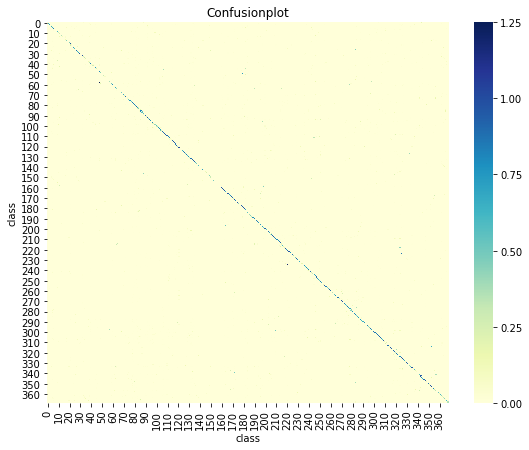

```python
import seaborn as sn
import pandas as pd
import matplotlib.pyplot as plt
f, ax = plt.subplots(figsize=(9, 7))
sn.heatmap(data=cm, cmap="YlGnBu")
plt.title('Confusionplot')
ax.set_xlabel('class')
ax.set_ylabel('class')
```

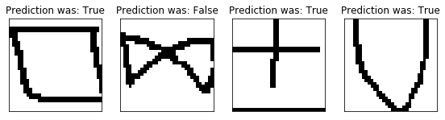

```python
import matplotlib.pyplot as plt
import matplotlib.cm as cm
import numpy as np
import numpy.random

from PIL import Image

random_rows=numpy.random.randint(0, 25000, size=5)
random_pictures=X_test[random_rows,:,:,:]
random_test_labels=np.argmax(y_test[random_rows],axis=1)
random_predict_labels=np.argmax(predict_test[random_rows],axis=1)

fig = plt.figure(figsize=(12,12))
for i in range(4):
    ax = fig.add_subplot(1, 5, i+1, xticks=[], yticks=[])
    img=(random_pictures[i,:,:,0]*255)
    ax.imshow(Image.fromarray(img), cmap='gray')
    ax.set_title('Prediction was: '+  str(random_test_labels[i]==random_predict_labels[i]))
```